# BTC_Signal_FH slides

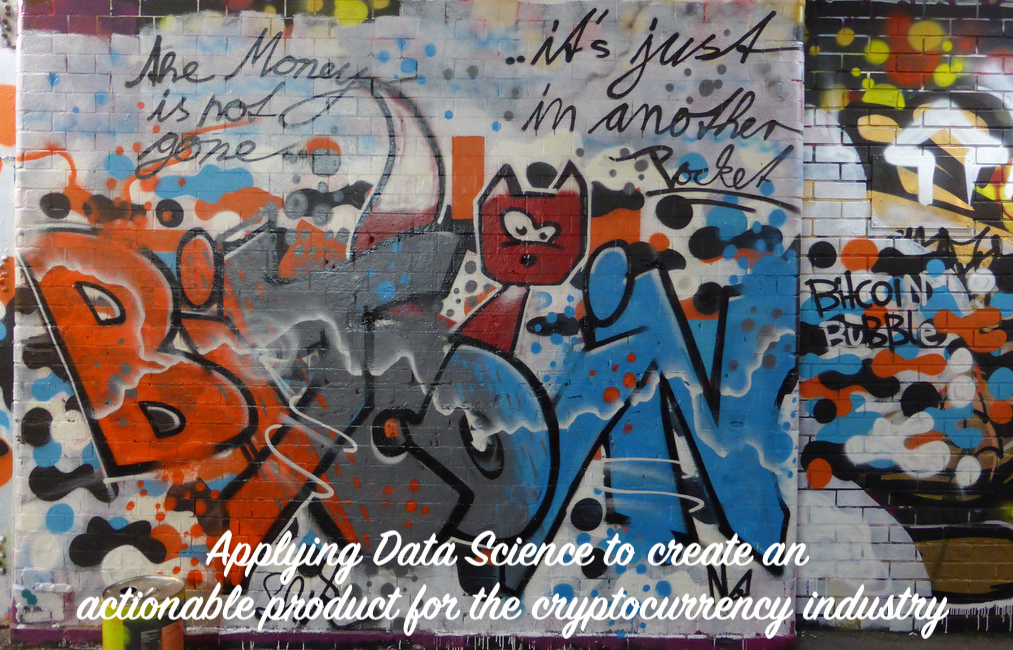

## Bitcoin (BTC): The world's first decentralized currency

- 18 August 2008, the domain name bitcoin.org was registered
- 31 October 2008, a link to a paper authored by Satoshi Nakamoto titled Bitcoin: A Peer-to-Peer Electronic Cash System was posted to a cryptography mailing list
- 3 January 2009, the bitcoin network came into existence with Satoshi Nakamoto mining the genesis block of bitcoin (block number 0), which had a reward of 50 bitcoins

### Key Features

- Governance: Decentralized
- Balances: Blockchain
- Transactions: Private Keys
- Processing: Mining

## Importance and Issues

- Bitcoin (BTC) is the largest cryptocurrency in existence today with a market capitalization of $174.5bn as of February 19, 2020
- For perspective, Bitcoin market value is larger than 468 of the companies that comprise the S&P 500 index
- The blockchain is immutable, all transactions are verified and published publicly
- The volatility of Bitcoin’s price has been a major issue
- The vast majority of the industry and investors focus on technical analysis and misinformation

## Current Trends

### Cryptocurrency Market

- The Bitcoin halving in May 2020
- 633,021 wallets (2.7%) hold 1,675,770 BTC (95.4%)

### Bitcoin Weekly Price Chart

[BTC Chart](https://www.tradingview.com/chart/583YISpV/) by TradingView

## Key Question

### Is the value of the network the driving factor behind Bitcoin's price?

- Can we identify changes in the network value using on-chain metrics and translate these into a signal that identifies the directional trend of Bitcoin prices for use in an algorithmic trading strategy
- After all, over $1.0bn is traded daily between investors thus making for an extremely compelling use case

## Proposed Product

#### Signal

- A weekly trend signal using on-chain metrics that provides a Long or Short Direction prediction for the upcoming week

#### Value

- A signal with high accuracy and recall is very valuable to end users including investors, traders, miners, service providers, and researchers involved with the blockchain industry

## Implementation

#### Data collection

- Data validation performed comparing Quandl, Glassnode, CoinGecko, Blockchain and CryptoCompare API data prior to selecting Quandl and Glassnode
- Data consists of historical daily price data from 2014-04-15 to the present day
- On-chain metrics historical data ranges vary with minimum of 8 years of daily data
- 30 API endpoints

#### Data Exploration

- Active Addresses, Unrealized Profit & Loss, Velocity, UTXO, Active Supply, Exchange Flows, MVRV Ratio, Spent Output Profit Ratio, BTC Circulation and Miner Hashrate

#### Feature Engineering

- Daily data was resampled into weeky data and converted to percentage change
- Features include Stock-to-Flow, Active Addresses-to-Active Entities and Moving Averages
- Top Features are the Weekly Change in Unrealized Profit & Loss and MVRV Ratio

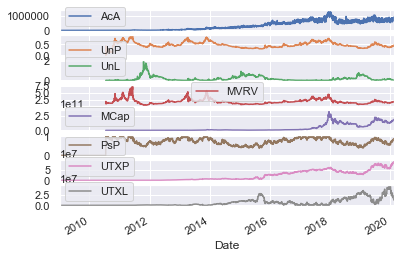

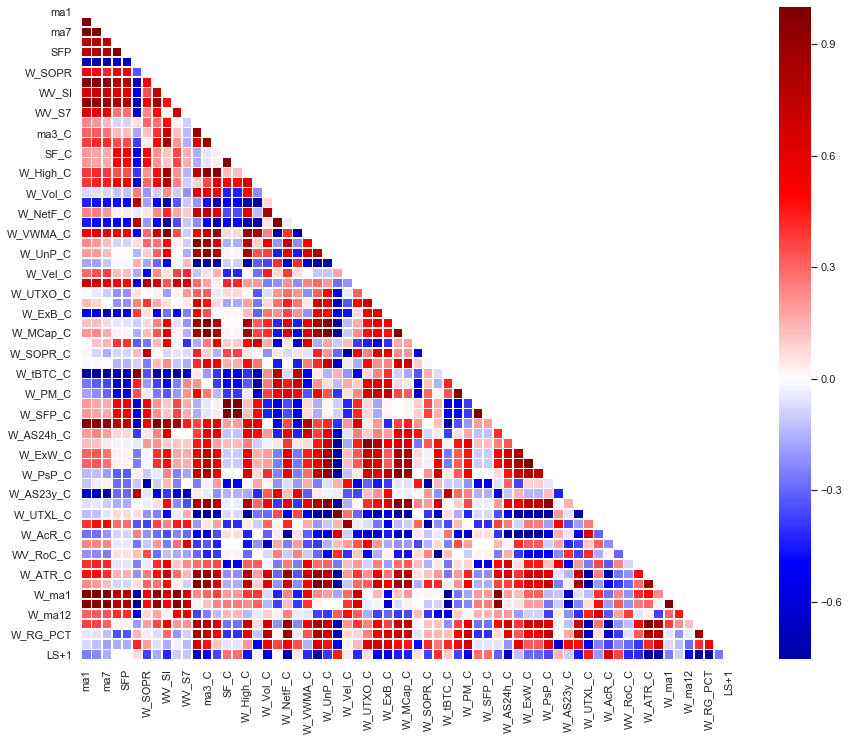

## Class Balance

[figure not shown]

## Modeling

### Supervised Learning

- Classic Models
- Ensemble Models
- Neural Networks

#### Unsupervised Learning

- K-Means for clustering

## Model Comparison

```
----- Classic and Ensemble Models -----

Logistic Regression Mean cross validation score: 0.697
Standard deviation of cross validation score: 0.088
Logistic Regression test score: 0.716

SVC Mean cross validation score: 0.691
Standard deviation of cross validation score: 0.107
SVC test score: 0.746

KNN Mean cross validation score: 0.715
Standard deviation of cross validation score: 0.109
KNN test score: 0.731

Random Forest Mean cross validation score: 0.721
Standard deviation of cross validation score: 0.080
Random Forest test score: 0.716

XGBoost Mean cross validation score: 0.679
XGBoost Standard deviation of cross validation score: 0.083
XGBoost test score: 0.731
```

```
----- Deep Learning Models -----

MLP Mean cross validation score: 0.509
MLP Standard deviation of cross validation score: 0.045
MLP test score: 0.478

Feed-Forward Test score: 0.559
Test accuracy: 0.716

CNN-LSTM Test score: 0.653
CNN-LSTM Test accuracy: 0.537

GRU Test score: 0.561
GRU Test accuracy: 0.731

LSTM Test score: 0.549
LSTM Test accuracy: 0.746

TS-LSTM Test score: 0.534
TS-LSTM Test accuracy: 0.814
```

## Sequential Timestep LSTM

```
Test score: 0.5340312557705378
Test accuracy: 0.8135593
Model: "sequential_45"
_________________________________________________________________
Layer (type)                 Output Shape              Param #
=================================================================
lstm_44 (LSTM)               (None, 28)                4480
_________________________________________________________________
dropout_45 (Dropout)         (None, 28)                0
_________________________________________________________________
dense_94 (Dense)             (None, 4)                 116
_________________________________________________________________
dense_95 (Dense)             (None, 1)                 5
=================================================================
Total params: 4,601
Trainable params: 4,601
Non-trainable params: 0
_________________________________________________________________
```

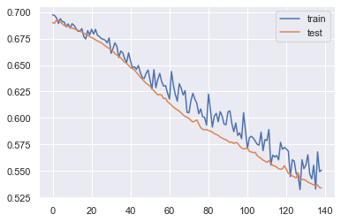

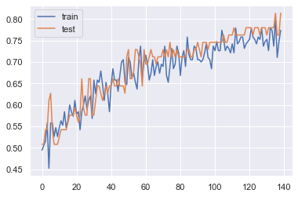

```
              precision    recall  f1-score   support

         0.0       0.85      0.77      0.81        30
         1.0       0.78      0.86      0.82        29

    accuracy                           0.81        59
   macro avg       0.82      0.81      0.81        59
weighted avg       0.82      0.81      0.81        59
```

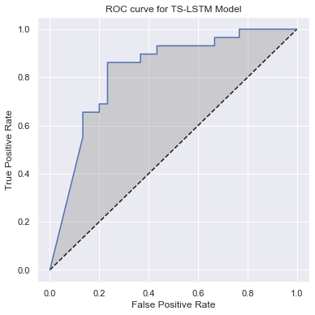

```
Area under the ROC curve: 0.825
```

## Model Deployment

- The TS-LSTM is the best performing model
- The model and scaler were saved for use in code that automatically pulls new weekly data and provides a forward prediction

## New Data Processing and Future Prediction

```
The prediction for the week of 2020-02-17 is Short
```

## Automated Order Execution System

[XBT Chart](https://www.tradingview.com/chart/t4nzRrmp/) by TradingView

- The signal is integrated into the indicator module of the automated order execution system that enters 3 to 4 long or short orders based on the signals output
- Orders are placed hourly based on a computation for liquidation levels of leveraged positions

## Results and Summary

- Performance since the signal was created using RFC & TS-LSTM from January 8th to February 16th is +32.7% v BTC +21.8% in the live account and from February 17th to February 20th using the fully automated TS-LSTM is +5.0% v BTC -3.2% in the test account

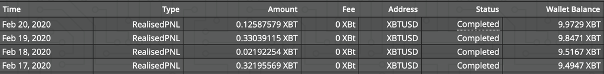

- The pricing of the APIs from the service providers currently ranges from Glassnode USD39 (Limited access and delayed) to USD599 for full access to TokenAnalyst at USD799 per month and ITB at Price on Request
- Data as costly as these services validates professional and enterprise demand for these services

## Future Work

- Scale the live trading account to 1.0 BTC
- Experiment with more complex Neural Networks using in reinforcement learning
- Extract the average leverage of BTC Perpetual Swaps using K-Means for clustering of the exchange orderbook data